# Effect of Gender and Time(0s, 30s, 60s and 90s) after Exercise on Blood Flow

Below are the Post hoc analysis done to find between which group there is difference.

2. Post Hoc Analysis : Pairwise T-test

```r
pairwise.t.test(x = df_flow_b$flow,
                g = df_flow_b$Cond,
                paired = FALSE,
                alternative = "two.sided",
                p.adjust.method = "bonferroni",
                var.equal = TRUE)
```

```
##
##  Pairwise comparisons using t tests with pooled SD
##
## data:  df_flow_b$flow and df_flow_b$Cond
##
##         Bike   Rest   Sprint
## Rest    0.8922 -      -
## Sprint  1.0000 1.0000 -
## Weights 0.0098 1e-05  0.0042
##
## P value adjustment method: bonferroni
```

```r
#Return Means and SD for each group
tapply(df_flow_b$flow, list(df_flow_b$Cond), mean)
```

```
##      Bike      Rest    Sprint   Weights
##  96.17034  86.36928  94.96459 117.70136
```

```r
tapply(df_flow_b$flow, list(df_flow_b$Cond), sd)
```

```
##     Bike     Rest   Sprint  Weights
## 36.04496 32.47025 40.32686 50.25073
```

```r
tapply(df_flow_b$flow, list(df_flow_b$Cond), length)
```

```
##    Bike    Rest  Sprint Weights
##      65      80      70      80
```

3. Post Hoc Analysis : Tukey’s HSD

```r
#Can also use Tukey's HSD
TukeyHSD(df_flow_b.ez[["aov"]])
```

```
##   Tukey multiple comparisons of means
##     95% family-wise confidence level
##
## Fit: aov(formula = formula(aov_formula), data = data)
##
## $Cond
##                     diff        lwr       upr     p adj
## Rest-Bike      -9.801063 -27.291280  7.689153 0.4705250
## Sprint-Bike    -1.205753 -19.247312 16.835805 0.9981663
## Weights-Bike   21.531026   4.040809 39.021242 0.0087897
## Sprint-Rest     8.595310  -8.546808 25.737428 0.5664481
## Weights-Rest   31.332089  14.771230 47.892948 0.0000100
## Weights-Sprint 22.736779   5.594661 39.878897 0.0038736
```

4. Comparison of p-values -
5. The p values of Bonferonni T-test and Tukey’s HSD are a bit different. However, the p values show that in terms of significance, both show the same result, i.e, for example weights-sprint comparison, the Bonferonni T-test p value(0.0042 < 0.05) is significant as well as Tukey’s HSD p-value (0.0038 < 0.05) shows a significant result.
2. The reason of the difference in the p-values is the way the two methods adjust the p-values. Although the Bonferonni T-test reduces the likelihood of making Type-1 error(by shrinking the alpha value), however, the likelihood of making Type II error increases.
3. On the other hand, Tukeys HSD method considers both the error terms. Further, Tukeys HSD controls the family-wise error rate by adjsting the p values for multiple testing. Therefore, whenenver the variance is equal across groups, Tukeys HSD is more reliable.

**Q3. Objective-** a. To examine whether flow changes over time through a one-way Anova. b. To create a classic Anova table. **Solution-** a. One-way Anova -

```r
df_flow_w.rm <- ezANOVA(data = df_flow,
                  dv = flow,
                  wid = ID,
                  within = time,
                  type = 3,
                  return_aov = TRUE)
df_flow_w.rm
```

```
## $ANOVA
##   Effect DFn DFd        F           p p<.05        ges
## 2   time   4 232 7.906497 5.44032e-06     * 0.04670337
##
## $`Mauchly's Test for Sphericity`
##   Effect         W           p p<.05
## 2   time 0.6633491 0.005874484     *
##
## $`Sphericity Corrections`
##   Effect       GGe        p[GG] p[GG]<.05       HFe        p[HF] p[HF]<.05
## 2   time 0.8547445 2.113715e-05         * 0.9147855 1.205134e-05         *
##
## $aov
##
## Call:
## aov(formula = formula(aov_formula), data = data)
##
## Grand Mean: 99.06523
##
## Stratum 1: ID
##
## Terms:
##                 Residuals
## Sum of Squares   317890.6
## Deg. of Freedom        58
##
## Residual standard error: 74.03292
##
## Stratum 2: ID:time
##
## Terms:
##                      time Residuals
## Sum of Squares   24311.02 178339.27
## Deg. of Freedom         4       232
##
## Residual standard error: 27.72551
## Estimated effects may be unbalanced
```

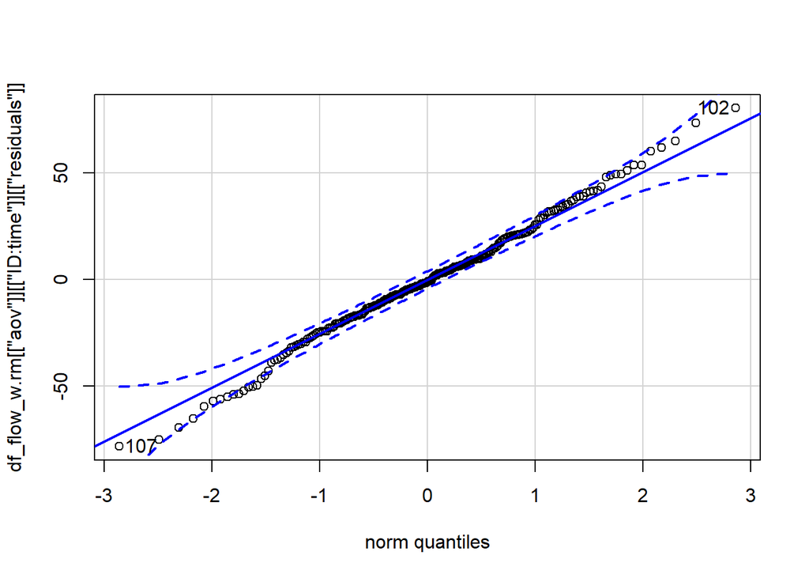

```
## 102 107
##  43  48
```

```r
#Check Assumptions
qqPlot(df_flow_w.rm[["aov"]][["ID:time"]][["residuals"]])
```

```r
skewness(df_flow_w.rm[["aov"]][["ID:time"]][["residuals"]])
```

```
## [1] -0.02733062
```

```r
kurtosis(df_flow_w.rm[["aov"]][["ID:time"]][["residuals"]])
```

```
## [1] 0.2914687
```

```r
ks.test(x = df_flow_w.rm[["aov"]][["ID:time"]][["residuals"]],
        y = "pnorm",
        mean = mean(df_flow_w.rm[["aov"]][["ID:time"]][["residuals"]]),
        sd = sd(df_flow_w.rm[["aov"]][["ID:time"]][["residuals"]]))
```

```
##
##  One-sample Kolmogorov-Smirnov test
##
## data:  df_flow_w.rm[["aov"]][["ID:time"]][["residuals"]]
## D = 0.044957, p-value = 0.7267
## alternative hypothesis: two-sided
```

By checking the assumptions, with p-value = 0.7267, we can assume normality.

Post-hoc test -

```r
#Repeated-Measures post-hoc:
pairwise.t.test(x = df_flow$flow,
                g = df_flow$time,
                paired = TRUE,
                alternative = "two.sided",
                p.adjust.method = "bonferroni",
                var.equal = TRUE)
```

```
##
##  Pairwise comparisons using paired t tests
##
## data:  df_flow$flow and df_flow$time
##
##      T0      T120    T30     T60
## T120 0.05629 -       -       -
## T30  0.00066 0.94889 -       -
## T60  0.02282 1.00000 1.00000 -
## T90  0.00061 0.42120 1.00000 0.50705
##
## P value adjustment method: bonferroni
```

```r
#Return Means and SD for each time
tapply(df_flow$flow, list(df_flow$time), mean)
```

```
##        T0      T120       T30       T60       T90
## 115.75498  99.10816  90.81478  98.66193  90.98632
```

```r
tapply(df_flow$flow, list(df_flow$time), sd)
```

```
##       T0     T120      T30      T60      T90
## 46.90256 42.95923 41.59991 37.95325 36.59700
```

```r
tapply(df_flow$flow, list(df_flow$time), length)
```

```
##   T0 T120  T30  T60  T90
##   59   59   59   59   59
```

[figure not shown]

```r
ggplot(data = df_flow, aes(x=time,y=flow, group = 1, fill = time))+
  stat_summary(geom = "line", fun.y = mean, size =1, color="red")+
  stat_summary(geom = "point", fun.y = mean, size =2, color="black", shape=17)+
  scale_x_discrete(name="time", limits=c("T0","T30","T60","T90","T120"))+
  labs(caption = "Figure 1 : Flow change at time 0, 30, 60, 90 and 120 min after the Sprint Exercise")+
  theme(plot.caption = element_text(hjust = 0.5), legend.position = "none")
```

b. ANOVA Table -

Source SS df MS F Time 24311.02 4 6077.755 7.906 Error 178339.27 232 768.703  
Subjects 317890.6 58 5480.87  
Total 520540.89 294 1770.547

Summary - A one-way repeated measure Anova was done to analyse the difference in blood flow over time. It was found that there was a statistically significant effect of time on blood flow (F=7.906497;P=5.44032e-06). The normality assumption was tested using the Kolmogorov-Smirnov test and it was found that distribution was not significantly different than normal(P = 0.726). Post hoc analysis revealed that flow decreases from time 0 min to 30 min (115.75 vs 90.81) after the exercise, then slightly increases and decreases alternately at time 60 min, 90 min and 120 min (98.66 vs 90.98 vs 99.10). It can observed that the change of flow with time is not in single direction(Refer fig 1).

**Q4. Objective-** a. To examine the difference between men and women for the blood flow response for all time(T0, T30, T60, T90 and T120) for Sprint exercise condition. b. To recreate the classic ANOVA table.

**Solution -**

```r
df3 <- df_flow %>%
  filter(Cond == "Sprint") %>%
  mutate(ID = factor(rep(seq(1,14,by=1),5)))

df3.ez <- ezANOVA(data = df3,
                   dv = flow,
                   wid = ID,
                   within = time,
                   between = Sex,
                   type = 2,
                   return_aov = TRUE)
df3.ez
```

```
## $ANOVA
##     Effect DFn DFd        F          p p<.05        ges
## 2      Sex   1  12 4.788175 0.04916712     * 0.18729875
## 3     time   4  48 2.662395 0.04369461     * 0.08568909
## 4 Sex:time   4  48 2.829278 0.03467551     * 0.09057373
##
## $`Mauchly's Test for Sphericity`
##     Effect         W         p p<.05
## 3     time 0.2995755 0.1889272
## 4 Sex:time 0.2995755 0.1889272
##
## $`Sphericity Corrections`
##     Effect      GGe      p[GG] p[GG]<.05       HFe      p[HF] p[HF]<.05
## 3     time 0.660267 0.07137634           0.8637173 0.05311425
## 4 Sex:time 0.660267 0.06038889           0.8637173 0.04323517         *
##
## $aov
##
## Call:
## aov(formula = formula(aov_formula), data = data)
##
## Grand Mean: 94.96459
##
## Stratum 1: ID
##
## Terms:
##                      Sex Residuals
## Sum of Squares  18163.49  45520.87
## Deg. of Freedom        1        12
##
## Residual standard error: 61.59063
## 4 out of 5 effects not estimable
## Estimated effects are balanced
##
## Stratum 2: ID:time
##
## Terms:
##                     time Sex:time Residuals
## Sum of Squares   7386.30  7849.29  33291.68
## Deg. of Freedom        4        4        48
##
## Residual standard error: 26.33584
## Estimated effects may be unbalanced
```

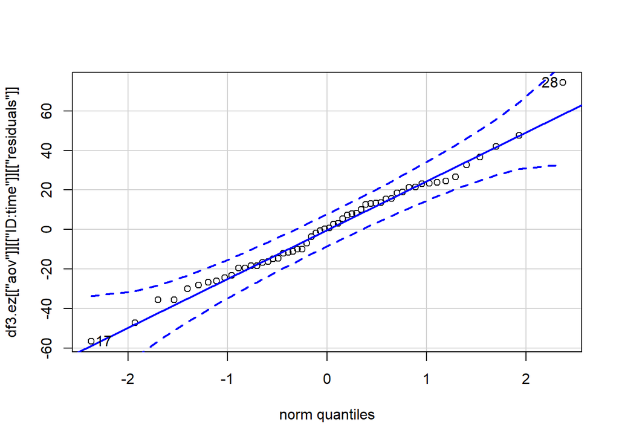

```
## 28 17
## 14  3
```

```r
#Check Assumptions (new qqPlot function)
qqPlot(df3.ez[["aov"]][["ID:time"]][["residuals"]])
```

```r
skewness(df3.ez[["aov"]][["ID:time"]][["residuals"]])
```

```
## [1] 0.2619592
```

```r
kurtosis(df3.ez[["aov"]][["ID:time"]][["residuals"]])
```

```
## [1] 0.230611
```

```r
ks.test(x = df3.ez[["aov"]][["ID:time"]][["residuals"]],
        y = "pnorm",
        mean =mean(df3.ez[["aov"]][["ID:time"]][["residuals"]]),
        sd = sd(df3.ez[["aov"]][["ID:time"]][["residuals"]]))
```

```
##
##  One-sample Kolmogorov-Smirnov test
##
## data:  df3.ez[["aov"]][["ID:time"]][["residuals"]]
## D = 0.074916, p-value = 0.8884
## alternative hypothesis: two-sided
```

Post-Hoc test : Independent t-test -

```r
#Comparison for Sex male and female should also have been done
# Independent t-test
df3.T0 <- df3 %>%
  filter(time == "T0")
pairwise.t.test(x = df3.T0$flow,
                g = df3.T0$Sex,
                paired = FALSE,
                alternative = "two.sided",
                p.adjust.method = "bonferroni")
```

```
##
##  Pairwise comparisons using t tests with pooled SD
##
## data:  df3.T0$flow and df3.T0$Sex
##
##   F
## M 0.03
##
## P value adjustment method: bonferroni
```

```r
df3.T30 <- df3 %>%
  filter(time == "T30")
pairwise.t.test(x = df3.T30$flow,
                g = df3.T30$Sex,
                paired = FALSE,
                alternative = "two.sided",
                p.adjust.method = "bonferroni")
```

```
##
##  Pairwise comparisons using t tests with pooled SD
##
## data:  df3.T30$flow and df3.T30$Sex
##
##   F
## M 0.94
##
## P value adjustment method: bonferroni
```

```r
df3.T60 <- df3 %>%
  filter(time == "T60")
pairwise.t.test(x = df3.T60$flow,
                g = df3.T60$Sex,
                paired = FALSE,
                alternative = "two.sided",
                p.adjust.method = "bonferroni")
```

```
##
##  Pairwise comparisons using t tests with pooled SD
##
## data:  df3.T60$flow and df3.T60$Sex
##
##   F
## M 0.0085
##
## P value adjustment method: bonferroni
```

```r
df3.T90 <- df3 %>%
  filter(time == "T90")
pairwise.t.test(x = df3.T90$flow,
                g = df3.T90$Sex,
                paired = FALSE,
                alternative = "two.sided",
                p.adjust.method = "bonferroni")
```

```
##
##  Pairwise comparisons using t tests with pooled SD
##
## data:  df3.T90$flow and df3.T90$Sex
##
##   F
## M 0.28
##
## P value adjustment method: bonferroni
```

```r
df3.T120 <- df3 %>%
  filter(time == "T120")
pairwise.t.test(x = df3.T120$flow,
                g = df3.T120$Sex,
                paired = FALSE,
                alternative = "two.sided",
                p.adjust.method = "bonferroni")
```

```
##
##  Pairwise comparisons using t tests with pooled SD
##
## data:  df3.T120$flow and df3.T120$Sex
##
##   F
## M 0.2
##
## P value adjustment method: bonferroni
```

```r
tapply(df3.T0$flow, list(df3.T0$Sex), mean)
```

```
##         F         M
##  68.43517 131.16854
```

```r
tapply(df3.T30$flow, list(df3.T30$Sex), mean)
```

```
##        F        M
## 76.62954 77.93337
```

```r
tapply(df3.T60$flow, list(df3.T60$Sex), mean)
```

```
##         F         M
##  66.82137 119.05217
```

```r
tapply(df3.T90$flow, list(df3.T90$Sex), mean)
```

```
##        F        M
##  81.5888 100.9860
```

```r
tapply(df3.T120$flow, list(df3.T120$Sex), mean)
```

```
##         F         M
##  73.29005 105.71506
```

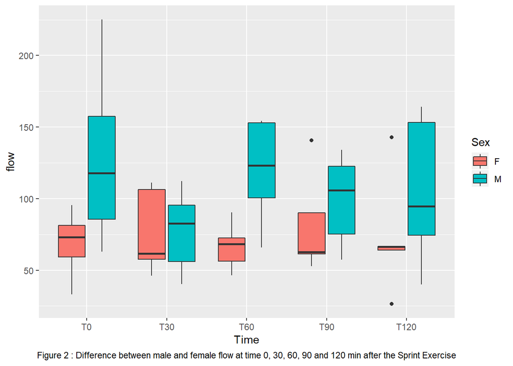

```r
ggplot(df3, aes(x=time, y=flow, fill=Sex)) +
  geom_boxplot()+
  scale_x_discrete(name="Time", limits=c("T0","T30","T60","T90","T120"))+
  labs(caption = "Figure 2 : Difference between male and female flow at time 0, 30, 60, 90 and 120 min after the Sprint Exercise")+
  theme(plot.caption = element_text(hjust = 0.5))
```

2. ANOVA Table

Source SS df MS F time(RM) 7386.30 4 1846.575 2.66 Sex(Between) 18163.49 1 18163.49 4.78 time x Sex 7849.29 4 1962.322 2.829 Subject Error 45520.87 12 3793.405  
Random Error 33291.68 48 693.57

Summary -

A 2X5 (2 groups at 5 timepoints) mixed ANOVA was done to examine the difference of flow between men and women over different time periods(0 min, 30 min, 60 min, 90 min and 120 min after the exercise) for Sprint condition. A significant main effect for Sex was found (F=4.78;P=0.049 ). A significant main effect for time was found (F=2.66, P=0.043). A significant Sex x time interaction was found (F=2.82, P=0.034). Sphercity assumption was tested using Mauchly’s Test for Sphericity(P = 0.18) as part of ANOVA and normality assumption was tested using the Kolmogorov-Smirnov test(P = 0.88). Both the assumptions were met. Post hoc analysis revealed that for the time 0 min and 60 min after the exercise, there was a significant difference between the flow of male and female as the flow in male is much greater than female (68.4 vs 131.16 at 0 min and 66.8 vs 119.05 at 60 min). Refer to the Figure 2 for reference.